# Risk Factor Analysis

## Outcome Variable

**Outcome Variable:** wasted

## Predictor Variables

**Intervention Variable:** rain_quartile

**Adjustment Set:**

unadjusted

## Stratifying Variables

The analysis was stratified on these variable(s):

- studyid
- country
- agecat

## Data Summary

| studyid | country | agecat | rain_quartile | wasted | n_cell | n |
| --- | --- | --- | --- | --- | --- | --- |
| CMC-V-BCS-2002 | India | Birth | 1 | 0 | 14 | 86 |
| CMC-V-BCS-2002 | India | Birth | 1 | 1 | 3 | 86 |
| CMC-V-BCS-2002 | India | Birth | 2 | 0 | 17 | 86 |
| CMC-V-BCS-2002 | India | Birth | 2 | 1 | 5 | 86 |
| CMC-V-BCS-2002 | India | Birth | 3 | 0 | 27 | 86 |
| CMC-V-BCS-2002 | India | Birth | 3 | 1 | 1 | 86 |
| CMC-V-BCS-2002 | India | Birth | 4 | 0 | 17 | 86 |
| CMC-V-BCS-2002 | India | Birth | 4 | 1 | 2 | 86 |
| CMC-V-BCS-2002 | India | 6 months | 1 | 0 | 95 | 368 |
| CMC-V-BCS-2002 | India | 6 months | 1 | 1 | 7 | 368 |
| CMC-V-BCS-2002 | India | 6 months | 2 | 0 | 101 | 368 |
| CMC-V-BCS-2002 | India | 6 months | 2 | 1 | 8 | 368 |
| CMC-V-BCS-2002 | India | 6 months | 3 | 0 | 78 | 368 |
| CMC-V-BCS-2002 | India | 6 months | 3 | 1 | 19 | 368 |
| CMC-V-BCS-2002 | India | 6 months | 4 | 0 | 48 | 368 |
| CMC-V-BCS-2002 | India | 6 months | 4 | 1 | 12 | 368 |
| CMC-V-BCS-2002 | India | 24 months | 1 | 0 | 98 | 372 |
| CMC-V-BCS-2002 | India | 24 months | 1 | 1 | 3 | 372 |
| CMC-V-BCS-2002 | India | 24 months | 2 | 0 | 92 | 372 |
| CMC-V-BCS-2002 | India | 24 months | 2 | 1 | 7 | 372 |
| CMC-V-BCS-2002 | India | 24 months | 3 | 0 | 109 | 372 |
| CMC-V-BCS-2002 | India | 24 months | 3 | 1 | 8 | 372 |
| CMC-V-BCS-2002 | India | 24 months | 4 | 0 | 50 | 372 |
| CMC-V-BCS-2002 | India | 24 months | 4 | 1 | 5 | 372 |
| CMIN | Bangladesh | Birth | 1 | 0 | 4 | 19 |
| CMIN | Bangladesh | Birth | 1 | 1 | 0 | 19 |
| CMIN | Bangladesh | Birth | 2 | 0 | 4 | 19 |
| CMIN | Bangladesh | Birth | 2 | 1 | 1 | 19 |
| CMIN | Bangladesh | Birth | 3 | 0 | 3 | 19 |
| CMIN | Bangladesh | Birth | 3 | 1 | 2 | 19 |

[output cut: 458 more lines]

The following strata were considered:

- studyid: CMC-V-BCS-2002, country: India, agecat: 24 months
- studyid: CMC-V-BCS-2002, country: India, agecat: 6 months
- studyid: CMC-V-BCS-2002, country: India, agecat: Birth
- studyid: CMIN, country: Bangladesh, agecat: 24 months
- studyid: CMIN, country: Bangladesh, agecat: 6 months
- studyid: CMIN, country: Bangladesh, agecat: Birth
- studyid: CONTENT, country: Peru, agecat: 24 months
- studyid: CONTENT, country: Peru, agecat: 6 months
- studyid: CONTENT, country: Peru, agecat: Birth
- studyid: EE, country: Pakistan, agecat: 24 months
- studyid: EE, country: Pakistan, agecat: 6 months
- studyid: EE, country: Pakistan, agecat: Birth
- studyid: GMS-Nepal, country: Nepal, agecat: 24 months
- studyid: GMS-Nepal, country: Nepal, agecat: 6 months
- studyid: GMS-Nepal, country: Nepal, agecat: Birth
- studyid: Guatemala BSC, country: Guatemala, agecat: 6 months
- studyid: IRC, country: India, agecat: 24 months
- studyid: IRC, country: India, agecat: 6 months
- studyid: IRC, country: India, agecat: Birth
- studyid: Keneba, country: Gambia, agecat: 24 months
- studyid: Keneba, country: Gambia, agecat: 6 months
- studyid: Keneba, country: Gambia, agecat: Birth
- studyid: LCNI-5, country: Malawi, agecat: 24 months
- studyid: LCNI-5, country: Malawi, agecat: 6 months
- studyid: MAL-ED, country: Bangladesh, agecat: 24 months
- studyid: MAL-ED, country: Bangladesh, agecat: 6 months
- studyid: MAL-ED, country: Bangladesh, agecat: Birth
- studyid: MAL-ED, country: Brazil, agecat: 24 months
- studyid: MAL-ED, country: Brazil, agecat: 6 months
- studyid: MAL-ED, country: Brazil, agecat: Birth
- studyid: MAL-ED, country: India, agecat: 24 months
- studyid: MAL-ED, country: India, agecat: 6 months
- studyid: MAL-ED, country: India, agecat: Birth
- studyid: MAL-ED, country: Nepal, agecat: 24 months
- studyid: MAL-ED, country: Nepal, agecat: 6 months
- studyid: MAL-ED, country: Nepal, agecat: Birth
- studyid: MAL-ED, country: Peru, agecat: 24 months
- studyid: MAL-ED, country: Peru, agecat: 6 months
- studyid: MAL-ED, country: Peru, agecat: Birth
- studyid: MAL-ED, country: South Africa, agecat: 24 months
- studyid: MAL-ED, country: South Africa, agecat: 6 months
- studyid: MAL-ED, country: South Africa, agecat: Birth
- studyid: MAL-ED, country: Tanzania, agecat: 24 months
- studyid: MAL-ED, country: Tanzania, agecat: 6 months
- studyid: MAL-ED, country: Tanzania, agecat: Birth
- studyid: PROBIT, country: Belarus, agecat: 24 months
- studyid: PROBIT, country: Belarus, agecat: 6 months
- studyid: PROBIT, country: Belarus, agecat: Birth
- studyid: PROVIDE, country: Bangladesh, agecat: 24 months
- studyid: PROVIDE, country: Bangladesh, agecat: 6 months
- studyid: PROVIDE, country: Bangladesh, agecat: Birth
- studyid: ResPak, country: Pakistan, agecat: 6 months
- studyid: ResPak, country: Pakistan, agecat: Birth
- studyid: SAS-CompFeed, country: India, agecat: 6 months
- studyid: SAS-CompFeed, country: India, agecat: Birth
- studyid: SAS-FoodSuppl, country: India, agecat: 6 months
- studyid: TanzaniaChild2, country: Tanzania, agecat: 24 months
- studyid: TanzaniaChild2, country: Tanzania, agecat: 6 months
- studyid: ZVITAMBO, country: Zimbabwe, agecat: 24 months
- studyid: ZVITAMBO, country: Zimbabwe, agecat: 6 months
- studyid: ZVITAMBO, country: Zimbabwe, agecat: Birth

### Dropped Strata

Some strata were dropped due to rare outcomes:

- studyid: CMC-V-BCS-2002, country: India, agecat: Birth
- studyid: CMC-V-BCS-2002, country: India, agecat: 24 months
- studyid: CMIN, country: Bangladesh, agecat: Birth
- studyid: CMIN, country: Bangladesh, agecat: 6 months
- studyid: CMIN, country: Bangladesh, agecat: 24 months
- studyid: CONTENT, country: Peru, agecat: Birth
- studyid: CONTENT, country: Peru, agecat: 6 months
- studyid: CONTENT, country: Peru, agecat: 24 months
- studyid: EE, country: Pakistan, agecat: Birth
- studyid: EE, country: Pakistan, agecat: 6 months
- studyid: EE, country: Pakistan, agecat: 24 months
- studyid: GMS-Nepal, country: Nepal, agecat: Birth
- studyid: GMS-Nepal, country: Nepal, agecat: 6 months
- studyid: GMS-Nepal, country: Nepal, agecat: 24 months
- studyid: Guatemala BSC, country: Guatemala, agecat: 6 months
- studyid: IRC, country: India, agecat: 24 months
- studyid: LCNI-5, country: Malawi, agecat: 6 months
- studyid: LCNI-5, country: Malawi, agecat: 24 months
- studyid: MAL-ED, country: Bangladesh, agecat: 6 months
- studyid: MAL-ED, country: Bangladesh, agecat: 24 months
- studyid: MAL-ED, country: Brazil, agecat: Birth
- studyid: MAL-ED, country: Brazil, agecat: 6 months
- studyid: MAL-ED, country: Brazil, agecat: 24 months
- studyid: MAL-ED, country: India, agecat: Birth
- studyid: MAL-ED, country: India, agecat: 6 months
- studyid: MAL-ED, country: India, agecat: 24 months
- studyid: MAL-ED, country: Nepal, agecat: Birth
- studyid: MAL-ED, country: Nepal, agecat: 6 months
- studyid: MAL-ED, country: Nepal, agecat: 24 months
- studyid: MAL-ED, country: Peru, agecat: Birth
- studyid: MAL-ED, country: Peru, agecat: 6 months
- studyid: MAL-ED, country: Peru, agecat: 24 months
- studyid: MAL-ED, country: South Africa, agecat: Birth
- studyid: MAL-ED, country: South Africa, agecat: 6 months
- studyid: MAL-ED, country: South Africa, agecat: 24 months
- studyid: MAL-ED, country: Tanzania, agecat: Birth
- studyid: MAL-ED, country: Tanzania, agecat: 6 months
- studyid: MAL-ED, country: Tanzania, agecat: 24 months
- studyid: PROVIDE, country: Bangladesh, agecat: 6 months
- studyid: ResPak, country: Pakistan, agecat: Birth
- studyid: ResPak, country: Pakistan, agecat: 6 months
- studyid: TanzaniaChild2, country: Tanzania, agecat: 24 months

## Methods Detail

We’re interested in the causal parameters $E[Y_a]$ for all values of $a \in \mathcal{A}$. These parameters represent the mean outcome if, possibly contrary to fact, we intervened to set all units to have $A=a$. Under the randomization and positivity assumptions, these are identified by the statistical parameters $\psi_a=E_W[E_{Y|A,W}(Y|A=a,W)]$. In addition, we’re interested in the mean of $Y$, $E[Y]$ under no intervention (the observed mean). We will estimate these parameters by using SuperLearner to fit the relevant likelihood factors – $E_{Y|A,W}(Y|A=a,W)$ and $p(A=a|W)$, and then updating our likelihood fit using a joint TMLE.

For unadjusted analyses ($W=\{\}$), initial likelihoods were estimated using Lrnr_glm to estimate the simple $E(Y|A)$ and Lrnr_mean to estimate $p(A)$. For adjusted analyses, a small library containing Lrnr_glmnet, Lrnr_xgboost, and Lrnr_mean was used.

Having estimated these parameters, we will then use the delta method to estimate relative risks and attributable risks relative to a prespecified baseline level of $A$.

# Results Detail

## Results Plots

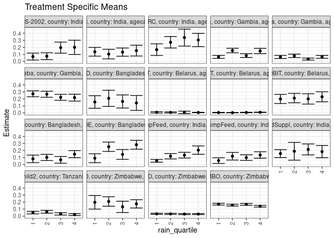

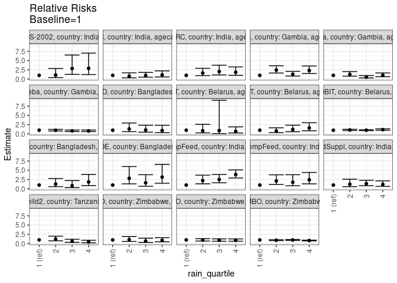

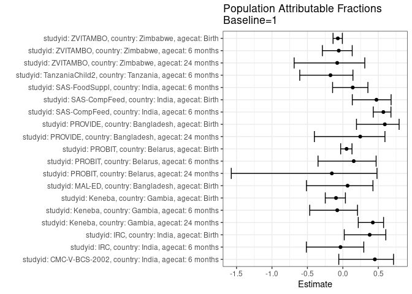

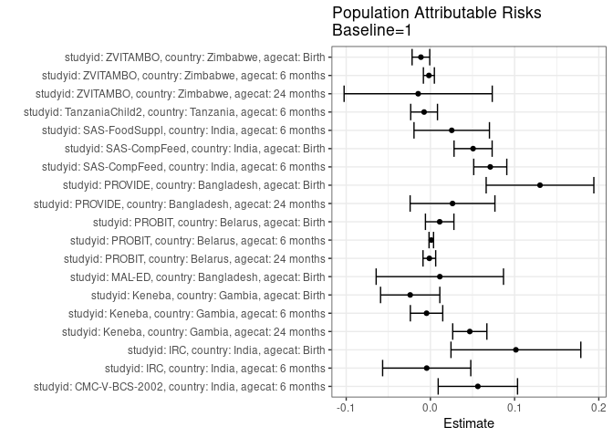

## Results Table

### Parameter: TSM

| studyid | country | agecat | intervention_level | baseline_level | estimate | ci_lower | ci_upper |
| --- | --- | --- | --- | --- | --- | --- | --- |
| CMC-V-BCS-2002 | India | 6 months | 1 | NA | 0.0686275 | 0.0194971 | 0.1177578 |
| CMC-V-BCS-2002 | India | 6 months | 2 | NA | 0.0733945 | 0.0243709 | 0.1224181 |
| CMC-V-BCS-2002 | India | 6 months | 3 | NA | 0.1958763 | 0.1167892 | 0.2749634 |
| CMC-V-BCS-2002 | India | 6 months | 4 | NA | 0.2000000 | 0.0986501 | 0.3013499 |
| IRC | India | Birth | 1 | NA | 0.1666667 | 0.0838403 | 0.2494930 |
| IRC | India | Birth | 2 | NA | 0.2719298 | 0.1901314 | 0.3537282 |
| IRC | India | Birth | 3 | NA | 0.3389831 | 0.2180204 | 0.4599457 |
| IRC | India | Birth | 4 | NA | 0.3043478 | 0.2101872 | 0.3985085 |
| IRC | India | 6 months | 1 | NA | 0.1367521 | 0.0744184 | 0.1990858 |
| IRC | India | 6 months | 2 | NA | 0.1038961 | 0.0356600 | 0.1721322 |
| IRC | India | 6 months | 3 | NA | 0.1317829 | 0.0733403 | 0.1902256 |
| IRC | India | 6 months | 4 | NA | 0.1529412 | 0.0763303 | 0.2295521 |
| Keneba | Gambia | Birth | 1 | NA | 0.2723005 | 0.2300149 | 0.3145860 |
| Keneba | Gambia | Birth | 2 | NA | 0.2668329 | 0.2235272 | 0.3101386 |
| Keneba | Gambia | Birth | 3 | NA | 0.2225275 | 0.1797830 | 0.2652719 |
| Keneba | Gambia | Birth | 4 | NA | 0.2181818 | 0.1693512 | 0.2670124 |
| Keneba | Gambia | 6 months | 1 | NA | 0.0625000 | 0.0404698 | 0.0845302 |
| Keneba | Gambia | 6 months | 2 | NA | 0.0784314 | 0.0538303 | 0.1030325 |
| Keneba | Gambia | 6 months | 3 | NA | 0.0329489 | 0.0187452 | 0.0471527 |
| Keneba | Gambia | 6 months | 4 | NA | 0.0644007 | 0.0440473 | 0.0847541 |
| Keneba | Gambia | 24 months | 1 | NA | 0.0638723 | 0.0424543 | 0.0852902 |
| Keneba | Gambia | 24 months | 2 | NA | 0.1544715 | 0.1225282 | 0.1864148 |
| Keneba | Gambia | 24 months | 3 | NA | 0.0824742 | 0.0550947 | 0.1098538 |
| Keneba | Gambia | 24 months | 4 | NA | 0.1478261 | 0.1103630 | 0.1852892 |
| MAL-ED | Bangladesh | Birth | 1 | NA | 0.1562500 | 0.0670864 | 0.2454136 |
| MAL-ED | Bangladesh | Birth | 2 | NA | 0.2083333 | 0.0931763 | 0.3234903 |
| MAL-ED | Bangladesh | Birth | 3 | NA | 0.1639344 | 0.0708128 | 0.2570561 |
| MAL-ED | Bangladesh | Birth | 4 | NA | 0.1428571 | 0.0367821 | 0.2489322 |
| PROBIT | Belarus | Birth | 1 | NA | 0.1993091 | 0.1342238 | 0.2643943 |
| PROBIT | Belarus | Birth | 2 | NA | 0.2114452 | 0.1443346 | 0.2785558 |
| PROBIT | Belarus | Birth | 3 | NA | 0.2000000 | 0.1267224 | 0.2732776 |
| PROBIT | Belarus | Birth | 4 | NA | 0.2303406 | 0.1590558 | 0.3016253 |
| PROBIT | Belarus | 6 months | 1 | NA | 0.0058027 | 0.0025368 | 0.0090686 |
| PROBIT | Belarus | 6 months | 2 | NA | 0.0044915 | 0.0019915 | 0.0069915 |
| PROBIT | Belarus | 6 months | 3 | NA | 0.0068736 | 0.0035214 | 0.0102258 |
| PROBIT | Belarus | 6 months | 4 | NA | 0.0093106 | 0.0063595 | 0.0122616 |
| PROBIT | Belarus | 24 months | 1 | NA | 0.0093110 | -0.0007900 | 0.0194119 |
| PROBIT | Belarus | 24 months | 2 | NA | 0.0079787 | 0.0002049 | 0.0157525 |
| PROBIT | Belarus | 24 months | 3 | NA | 0.0083832 | -0.0086500 | 0.0254164 |
| PROBIT | Belarus | 24 months | 4 | NA | 0.0064309 | 0.0031844 | 0.0096773 |
| PROVIDE | Bangladesh | Birth | 1 | NA | 0.0897436 | 0.0262554 | 0.1532318 |
| PROVIDE | Bangladesh | Birth | 2 | NA | 0.2530864 | 0.1860719 | 0.3201009 |
| PROVIDE | Bangladesh | Birth | 3 | NA | 0.1443299 | 0.0743292 | 0.2143306 |
| PROVIDE | Bangladesh | Birth | 4 | NA | 0.2820513 | 0.2188319 | 0.3452706 |
| PROVIDE | Bangladesh | 24 months | 1 | NA | 0.0808081 | 0.0270757 | 0.1345405 |
| PROVIDE | Bangladesh | 24 months | 2 | NA | 0.1016043 | 0.0582639 | 0.1449446 |
| PROVIDE | Bangladesh | 24 months | 3 | NA | 0.0673077 | 0.0191120 | 0.1155034 |
| PROVIDE | Bangladesh | 24 months | 4 | NA | 0.1481481 | 0.0974581 | 0.1988382 |
| SAS-CompFeed | India | Birth | 1 | NA | 0.0562771 | 0.0162749 | 0.0962792 |
| SAS-CompFeed | India | Birth | 2 | NA | 0.1185984 | 0.0647981 | 0.1723987 |
| SAS-CompFeed | India | Birth | 3 | NA | 0.0989583 | 0.0595568 | 0.1383599 |
| SAS-CompFeed | India | Birth | 4 | NA | 0.1359223 | 0.0899483 | 0.1818964 |
| SAS-CompFeed | India | 6 months | 1 | NA | 0.0533333 | 0.0334905 | 0.0731762 |
| SAS-CompFeed | India | 6 months | 2 | NA | 0.1184211 | 0.0799919 | 0.1568502 |
| SAS-CompFeed | India | 6 months | 3 | NA | 0.1336406 | 0.0929308 | 0.1743503 |
| SAS-CompFeed | India | 6 months | 4 | NA | 0.2053872 | 0.1459476 | 0.2648268 |
| SAS-FoodSuppl | India | 6 months | 1 | NA | 0.1562500 | 0.0999151 | 0.2125849 |
| SAS-FoodSuppl | India | 6 months | 2 | NA | 0.1891892 | 0.0628240 | 0.3155543 |
| SAS-FoodSuppl | India | 6 months | 3 | NA | 0.2149533 | 0.1370155 | 0.2928911 |
| SAS-FoodSuppl | India | 6 months | 4 | NA | 0.1842105 | 0.0969416 | 0.2714795 |
| TanzaniaChild2 | Tanzania | 6 months | 1 | NA | 0.0503876 | 0.0315092 | 0.0692660 |
| TanzaniaChild2 | Tanzania | 6 months | 2 | NA | 0.0620567 | 0.0421409 | 0.0819726 |
| TanzaniaChild2 | Tanzania | 6 months | 3 | NA | 0.0321199 | 0.0161245 | 0.0481153 |
| TanzaniaChild2 | Tanzania | 6 months | 4 | NA | 0.0228690 | 0.0095067 | 0.0362314 |
| ZVITAMBO | Zimbabwe | Birth | 1 | NA | 0.1707732 | 0.1583606 | 0.1831857 |
| ZVITAMBO | Zimbabwe | Birth | 2 | NA | 0.1571330 | 0.1438917 | 0.1703743 |
| ZVITAMBO | Zimbabwe | Birth | 3 | NA | 0.1677479 | 0.1548758 | 0.1806200 |
| ZVITAMBO | Zimbabwe | Birth | 4 | NA | 0.1410967 | 0.1291205 | 0.1530730 |
| ZVITAMBO | Zimbabwe | 6 months | 1 | NA | 0.0329567 | 0.0253641 | 0.0405493 |
| ZVITAMBO | Zimbabwe | 6 months | 2 | NA | 0.0318327 | 0.0244947 | 0.0391706 |
| ZVITAMBO | Zimbabwe | 6 months | 3 | NA | 0.0299189 | 0.0223992 | 0.0374385 |
| ZVITAMBO | Zimbabwe | 6 months | 4 | NA | 0.0298643 | 0.0227673 | 0.0369612 |
| ZVITAMBO | Zimbabwe | 24 months | 1 | NA | 0.1969697 | 0.1009094 | 0.2930300 |
| ZVITAMBO | Zimbabwe | 24 months | 2 | NA | 0.2086331 | 0.1410056 | 0.2762606 |
| ZVITAMBO | Zimbabwe | 24 months | 3 | NA | 0.1323529 | 0.0517160 | 0.2129899 |
| ZVITAMBO | Zimbabwe | 24 months | 4 | NA | 0.1750000 | 0.1160565 | 0.2339435 |

### Parameter: E(Y)

| studyid | country | agecat | intervention_level | baseline_level | estimate | ci_lower | ci_upper |
| --- | --- | --- | --- | --- | --- | --- | --- |
| CMC-V-BCS-2002 | India | 6 months | NA | NA | 0.1250000 | 0.0911644 | 0.1588356 |
| IRC | India | Birth | NA | NA | 0.2682216 | 0.2212677 | 0.3151755 |
| IRC | India | 6 months | NA | NA | 0.1323529 | 0.0994307 | 0.1652752 |
| Keneba | Gambia | Birth | NA | NA | 0.2482947 | 0.2261720 | 0.2704173 |
| Keneba | Gambia | 6 months | NA | NA | 0.0579225 | 0.0479029 | 0.0679420 |
| Keneba | Gambia | 24 months | NA | NA | 0.1106605 | 0.0958563 | 0.1254646 |
| MAL-ED | Bangladesh | Birth | NA | NA | 0.1674419 | 0.1174176 | 0.2174661 |
| PROBIT | Belarus | Birth | NA | NA | 0.2103206 | 0.1450833 | 0.2755580 |
| PROBIT | Belarus | 6 months | NA | NA | 0.0068541 | 0.0051915 | 0.0085167 |
| PROBIT | Belarus | 24 months | NA | NA | 0.0080605 | 0.0022677 | 0.0138532 |
| PROVIDE | Bangladesh | Birth | NA | NA | 0.2199248 | 0.1846953 | 0.2551543 |
| PROVIDE | Bangladesh | 24 months | NA | NA | 0.1070812 | 0.0818727 | 0.1322897 |
| SAS-CompFeed | India | Birth | NA | NA | 0.1069810 | 0.0760961 | 0.1378659 |
| SAS-CompFeed | India | 6 months | NA | NA | 0.1244378 | 0.0992652 | 0.1496104 |
| SAS-FoodSuppl | India | 6 months | NA | NA | 0.1815789 | 0.1427684 | 0.2203895 |
| TanzaniaChild2 | Tanzania | 6 months | NA | NA | 0.0428994 | 0.0340782 | 0.0517206 |
| ZVITAMBO | Zimbabwe | Birth | NA | NA | 0.1594921 | 0.1531776 | 0.1658066 |
| ZVITAMBO | Zimbabwe | 6 months | NA | NA | 0.0311581 | 0.0274654 | 0.0348509 |
| ZVITAMBO | Zimbabwe | 24 months | NA | NA | 0.1824480 | 0.1460286 | 0.2188675 |

### Parameter: RR

| studyid | country | agecat | intervention_level | baseline_level | estimate | ci_lower | ci_upper |
| --- | --- | --- | --- | --- | --- | --- | --- |
| CMC-V-BCS-2002 | India | 6 months | 1 | 1 | 1.0000000 | 1.0000000 | 1.0000000 |
| CMC-V-BCS-2002 | India | 6 months | 2 | 1 | 1.0694626 | 0.4017372 | 2.8470113 |
| CMC-V-BCS-2002 | India | 6 months | 3 | 1 | 2.8541973 | 1.2546821 | 6.4928342 |
| CMC-V-BCS-2002 | India | 6 months | 4 | 1 | 2.9142857 | 1.2123053 | 7.0057118 |
| IRC | India | Birth | 1 | 1 | 1.0000000 | 1.0000000 | 1.0000000 |
| IRC | India | Birth | 2 | 1 | 1.6315789 | 0.9126908 | 2.9167051 |
| IRC | India | Birth | 3 | 1 | 2.0338983 | 1.1031304 | 3.7500030 |
| IRC | India | Birth | 4 | 1 | 1.8260870 | 1.0169228 | 3.2791021 |
| IRC | India | 6 months | 1 | 1 | 1.0000000 | 1.0000000 | 1.0000000 |
| IRC | India | 6 months | 2 | 1 | 0.7597403 | 0.3415616 | 1.6899008 |
| IRC | India | 6 months | 3 | 1 | 0.9636628 | 0.5101916 | 1.8201906 |
| IRC | India | 6 months | 4 | 1 | 1.1183824 | 0.5681442 | 2.2015170 |
| Keneba | Gambia | Birth | 1 | 1 | 1.0000000 | 1.0000000 | 1.0000000 |
| Keneba | Gambia | Birth | 2 | 1 | 0.9799209 | 0.7827791 | 1.2267125 |
| Keneba | Gambia | Birth | 3 | 1 | 0.8172130 | 0.6383543 | 1.0461855 |
| Keneba | Gambia | Birth | 4 | 1 | 0.8012539 | 0.6101915 | 1.0521415 |
| Keneba | Gambia | 6 months | 1 | 1 | 1.0000000 | 1.0000000 | 1.0000000 |
| Keneba | Gambia | 6 months | 2 | 1 | 1.2549020 | 0.7828775 | 2.0115266 |
| Keneba | Gambia | 6 months | 3 | 1 | 0.5271829 | 0.3020828 | 0.9200186 |
| Keneba | Gambia | 6 months | 4 | 1 | 1.0304114 | 0.6418100 | 1.6543022 |
| Keneba | Gambia | 24 months | 1 | 1 | 1.0000000 | 1.0000000 | 1.0000000 |
| Keneba | Gambia | 24 months | 2 | 1 | 2.4184451 | 1.6309512 | 3.5861752 |
| Keneba | Gambia | 24 months | 3 | 1 | 1.2912371 | 0.8055264 | 2.0698183 |
| Keneba | Gambia | 24 months | 4 | 1 | 2.3144022 | 1.5201849 | 3.5235565 |
| MAL-ED | Bangladesh | Birth | 1 | 1 | 1.0000000 | 1.0000000 | 1.0000000 |
| MAL-ED | Bangladesh | Birth | 2 | 1 | 1.3333333 | 0.6024307 | 2.9510081 |
| MAL-ED | Bangladesh | Birth | 3 | 1 | 1.0491803 | 0.4689929 | 2.3471128 |
| MAL-ED | Bangladesh | Birth | 4 | 1 | 0.9142857 | 0.3584073 | 2.3323141 |
| PROBIT | Belarus | Birth | 1 | 1 | 1.0000000 | 1.0000000 | 1.0000000 |
| PROBIT | Belarus | Birth | 2 | 1 | 1.0608910 | 0.9039303 | 1.2451069 |
| PROBIT | Belarus | Birth | 3 | 1 | 1.0034667 | 0.8907417 | 1.1304572 |
| PROBIT | Belarus | Birth | 4 | 1 | 1.1556954 | 0.9730329 | 1.3726482 |
| PROBIT | Belarus | 6 months | 1 | 1 | 1.0000000 | 1.0000000 | 1.0000000 |
| PROBIT | Belarus | 6 months | 2 | 1 | 0.7740349 | 0.3631780 | 1.6496868 |
| PROBIT | Belarus | 6 months | 3 | 1 | 1.1845528 | 0.5937321 | 2.3632974 |
| PROBIT | Belarus | 6 months | 4 | 1 | 1.6045223 | 0.8491827 | 3.0317288 |
| PROBIT | Belarus | 24 months | 1 | 1 | 1.0000000 | 1.0000000 | 1.0000000 |
| PROBIT | Belarus | 24 months | 2 | 1 | 0.8569149 | 0.2833195 | 2.5917849 |
| PROBIT | Belarus | 24 months | 3 | 1 | 0.9003593 | 0.0893233 | 9.0754217 |
| PROBIT | Belarus | 24 months | 4 | 1 | 0.6906752 | 0.2509947 | 1.9005672 |
| PROVIDE | Bangladesh | Birth | 1 | 1 | 1.0000000 | 1.0000000 | 1.0000000 |
| PROVIDE | Bangladesh | Birth | 2 | 1 | 2.8201058 | 1.3249889 | 6.0023119 |
| PROVIDE | Bangladesh | Birth | 3 | 1 | 1.6082474 | 0.6820960 | 3.7919291 |
| PROVIDE | Bangladesh | Birth | 4 | 1 | 3.1428571 | 1.4963572 | 6.6010649 |
| PROVIDE | Bangladesh | 24 months | 1 | 1 | 1.0000000 | 1.0000000 | 1.0000000 |
| PROVIDE | Bangladesh | 24 months | 2 | 1 | 1.2573529 | 0.5706441 | 2.7704419 |
| PROVIDE | Bangladesh | 24 months | 3 | 1 | 0.8329327 | 0.3134931 | 2.2130527 |
| PROVIDE | Bangladesh | 24 months | 4 | 1 | 1.8333333 | 0.8679066 | 3.8726647 |
| SAS-CompFeed | India | Birth | 1 | 1 | 1.0000000 | 1.0000000 | 1.0000000 |
| SAS-CompFeed | India | Birth | 2 | 1 | 2.1074020 | 1.1777577 | 3.7708464 |
| SAS-CompFeed | India | Birth | 3 | 1 | 1.7584135 | 0.8156200 | 3.7910032 |
| SAS-CompFeed | India | Birth | 4 | 1 | 2.4152353 | 1.3248595 | 4.4030037 |
| SAS-CompFeed | India | 6 months | 1 | 1 | 1.0000000 | 1.0000000 | 1.0000000 |
| SAS-CompFeed | India | 6 months | 2 | 1 | 2.2203947 | 1.3424844 | 3.6724098 |
| SAS-CompFeed | India | 6 months | 3 | 1 | 2.5057604 | 1.6225471 | 3.8697397 |
| SAS-CompFeed | India | 6 months | 4 | 1 | 3.8510101 | 2.9084771 | 5.0989841 |
| SAS-FoodSuppl | India | 6 months | 1 | 1 | 1.0000000 | 1.0000000 | 1.0000000 |
| SAS-FoodSuppl | India | 6 months | 2 | 1 | 1.2108108 | 0.5668068 | 2.5865300 |
| SAS-FoodSuppl | India | 6 months | 3 | 1 | 1.3757009 | 0.8250065 | 2.2939857 |
| SAS-FoodSuppl | India | 6 months | 4 | 1 | 1.1789474 | 0.6500440 | 2.1381889 |
| TanzaniaChild2 | Tanzania | 6 months | 1 | 1 | 1.0000000 | 1.0000000 | 1.0000000 |
| TanzaniaChild2 | Tanzania | 6 months | 2 | 1 | 1.2315876 | 0.7519992 | 2.0170339 |
| TanzaniaChild2 | Tanzania | 6 months | 3 | 1 | 0.6374568 | 0.3418239 | 1.1887732 |
| TanzaniaChild2 | Tanzania | 6 months | 4 | 1 | 0.4538621 | 0.2267144 | 0.9085920 |
| ZVITAMBO | Zimbabwe | Birth | 1 | 1 | 1.0000000 | 1.0000000 | 1.0000000 |
| ZVITAMBO | Zimbabwe | Birth | 2 | 1 | 0.9201271 | 0.8232236 | 1.0284375 |
| ZVITAMBO | Zimbabwe | Birth | 3 | 1 | 0.9822851 | 0.8837615 | 1.0917923 |
| ZVITAMBO | Zimbabwe | Birth | 4 | 1 | 0.8262232 | 0.7388662 | 0.9239085 |
| ZVITAMBO | Zimbabwe | 6 months | 1 | 1 | 1.0000000 | 1.0000000 | 1.0000000 |
| ZVITAMBO | Zimbabwe | 6 months | 2 | 1 | 0.9658936 | 0.6972544 | 1.3380344 |
| ZVITAMBO | Zimbabwe | 6 months | 3 | 1 | 0.9078238 | 0.6455507 | 1.2766527 |
| ZVITAMBO | Zimbabwe | 6 months | 4 | 1 | 0.9061668 | 0.6508265 | 1.2616854 |
| ZVITAMBO | Zimbabwe | 24 months | 1 | 1 | 1.0000000 | 1.0000000 | 1.0000000 |
| ZVITAMBO | Zimbabwe | 24 months | 2 | 1 | 1.0592142 | 0.5897479 | 1.9023970 |
| ZVITAMBO | Zimbabwe | 24 months | 3 | 1 | 0.6719457 | 0.3078984 | 1.4664287 |
| ZVITAMBO | Zimbabwe | 24 months | 4 | 1 | 0.8884615 | 0.4911719 | 1.6071033 |

### Parameter: PAR

| studyid | country | agecat | intervention_level | baseline_level | estimate | ci_lower | ci_upper |
| --- | --- | --- | --- | --- | --- | --- | --- |
| CMC-V-BCS-2002 | India | 6 months | 1 | NA | 0.0563725 | 0.0092497 | 0.1034954 |
| IRC | India | Birth | 1 | NA | 0.1015549 | 0.0244525 | 0.1786573 |
| IRC | India | 6 months | 1 | NA | -0.0043992 | -0.0567530 | 0.0479546 |
| Keneba | Gambia | Birth | 1 | NA | -0.0240058 | -0.0591953 | 0.0111837 |
| Keneba | Gambia | 6 months | 1 | NA | -0.0045775 | -0.0238161 | 0.0146610 |
| Keneba | Gambia | 24 months | 1 | NA | 0.0467882 | 0.0265007 | 0.0670758 |
| MAL-ED | Bangladesh | Birth | 1 | NA | 0.0111919 | -0.0644352 | 0.0868190 |
| PROBIT | Belarus | Birth | 1 | NA | 0.0110116 | -0.0059017 | 0.0279248 |
| PROBIT | Belarus | 6 months | 1 | NA | 0.0010514 | -0.0016243 | 0.0037270 |
| PROBIT | Belarus | 24 months | 1 | NA | -0.0012505 | -0.0087797 | 0.0062786 |
| PROVIDE | Bangladesh | Birth | 1 | NA | 0.1301812 | 0.0662288 | 0.1941337 |
| PROVIDE | Bangladesh | 24 months | 1 | NA | 0.0262731 | -0.0240788 | 0.0766250 |
| SAS-CompFeed | India | Birth | 1 | NA | 0.0507039 | 0.0280808 | 0.0733270 |
| SAS-CompFeed | India | 6 months | 1 | NA | 0.0711044 | 0.0514783 | 0.0907306 |
| SAS-FoodSuppl | India | 6 months | 1 | NA | 0.0253289 | -0.0194746 | 0.0701325 |
| TanzaniaChild2 | Tanzania | 6 months | 1 | NA | -0.0074882 | -0.0233893 | 0.0084130 |
| ZVITAMBO | Zimbabwe | Birth | 1 | NA | -0.0112810 | -0.0217550 | -0.0008071 |
| ZVITAMBO | Zimbabwe | 6 months | 1 | NA | -0.0017985 | -0.0083170 | 0.0047199 |
| ZVITAMBO | Zimbabwe | 24 months | 1 | NA | -0.0145217 | -0.1025042 | 0.0734609 |

### Parameter: PAF

| studyid | country | agecat | intervention_level | baseline_level | estimate | ci_lower | ci_upper |
| --- | --- | --- | --- | --- | --- | --- | --- |
| CMC-V-BCS-2002 | India | 6 months | 1 | NA | 0.4509804 | -0.0575661 | 0.7149847 |
| IRC | India | Birth | 1 | NA | 0.3786232 | 0.0197505 | 0.6061114 |
| IRC | India | 6 months | 1 | NA | -0.0332384 | -0.5150945 | 0.2953697 |
| Keneba | Gambia | Birth | 1 | NA | -0.0966827 | -0.2478904 | 0.0362031 |
| Keneba | Gambia | 6 months | 1 | NA | -0.0790289 | -0.4676356 | 0.2066809 |
| Keneba | Gambia | 24 months | 1 | NA | 0.4228088 | 0.2174331 | 0.5742861 |
| MAL-ED | Bangladesh | Birth | 1 | NA | 0.0668403 | -0.5136727 | 0.4247190 |
| PROBIT | Belarus | Birth | 1 | NA | 0.0523561 | -0.0309034 | 0.1288912 |
| PROBIT | Belarus | 6 months | 1 | NA | 0.1533957 | -0.3502767 | 0.4691911 |
| PROBIT | Belarus | 24 months | 1 | NA | -0.1551443 | -1.5742018 | 0.4816419 |
| PROVIDE | Bangladesh | Birth | 1 | NA | 0.5919351 | 0.1922535 | 0.7938500 |
| PROVIDE | Bangladesh | 24 months | 1 | NA | 0.2453568 | -0.4017659 | 0.5937365 |
| SAS-CompFeed | India | Birth | 1 | NA | 0.4739526 | 0.1332308 | 0.6807387 |
| SAS-CompFeed | India | 6 months | 1 | NA | 0.5714056 | 0.4287222 | 0.6784521 |
| SAS-FoodSuppl | India | 6 months | 1 | NA | 0.1394928 | -0.1447798 | 0.3531745 |
| TanzaniaChild2 | Tanzania | 6 months | 1 | NA | -0.1745523 | -0.6082349 | 0.1421819 |
| ZVITAMBO | Zimbabwe | Birth | 1 | NA | -0.0707311 | -0.1384200 | -0.0070668 |
| ZVITAMBO | Zimbabwe | 6 months | 1 | NA | -0.0577231 | -0.2889263 | 0.1320077 |
| ZVITAMBO | Zimbabwe | 24 months | 1 | NA | -0.0795934 | -0.6873167 | 0.3092453 |